# Tutorial 3b: Population structure and Admixture

In this session you will learn how to use low-coverage whole genome data to do:

- Principal Components Analysis (PCA)
- Admixture analysis

# Today’s data

As outlined in the previous exercises, we have low-coverage NGS data for 60 Atlantic silversides from the following 4 populations:

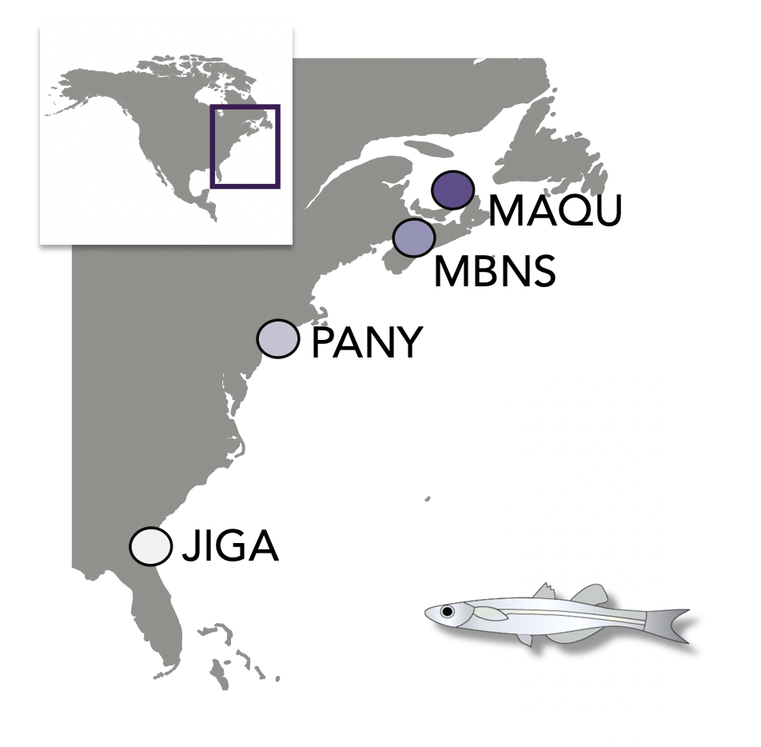

These populations have been previously studied in [Therkildsen et al. 2019](https://science.sciencemag.org/content/365/6452/487) and [Wilder et al. 2020](https://onlinelibrary.wiley.com/doi/10.1002/evl3.189), and cover the entire distribution range of Atlantic silverside.

Our NGS data are in bam format and span a 2Mb region on chromosome 24. The interesting aspect about chromosome 24 is that it harbours a large polymorphic inversion that differs in its frequency across populations. The test dataset spans one breakpoint of this inversion (1Mb up and downstream).

In this tutorial, we want to use these data to determine the population structure of Atlantic silverside along its distribution range using principal components analysis (PCA)and admixture analysis. In addition, we will use principal components analysis and ancestry analyses to determine which populations most likely contain alternative inversion karyotypes.

For this practical, we will be using ANGSD (Analysis of Next Generation Sequencing Data), [ngsAdmix](http://www.popgen.dk/software/index.php/NgsAdmix) and PCAngsd.

# Initial preparation

Please make sure to follow these preparatory instructions below before running these examples. Briefly, you need to set the path to the software and various data that will be used. Also, you will have to create two folders on your working directory, one for your results and one for your intermediate data.

First make sure you are in your home directory

```
cd ~
```

Then create a folder for this session and go into this folder:

```
mkdir day3
cd day3
```

When you are in the `~/day3` folder, you can create the subfolders for data and results:

```
mkdir Results
mkdir Data
```

And then we set all the paths:

[output not shown]

# Principal components analysis (PCA)

To perform PCA with low-coverage NGS data, we have to infer the genetic covariance matrix, which can be estimated in different ways. Here we will estimate the covariance matrix using single-read sampling in [ANGSD](http://www.popgen.dk/angsd/index.php/PCA_MDS) as discussed during the lecture, but will also show you how to estimate the covariance matrix usingPCAngsd

The first question is how our input dataset should look like?

We only want to focus on variant sites in our population structure analyses. As we have learnt yesterday, we could just perform SNP calling in ANGSD and get a list of all variant sites in our dataset (WE ARE NOT RUNNING THIS CODE TODAY)

```
# angsd -b ALL_bams.txt -anc $REF -out Results/MME_SNPs \
#   -minMapQ 20 -minQ 20 -doMaf 1 -minMaf 0.05 -SNP_pval 2e-6 \
#   -GL 1 -doGlf 2 -doMajorMinor 1 -doPost 1
```

We could3 then extract a list of all variant sites from the minor allele frequency file:

```
#gunzip -c MME_SNPs.mafs.gz' | cut -f 1,2,3,4 | tail -n +2 > Global_SNPList_MME_SNPs.txt
```

And then we have to index our SNP list so that ANGSD can read it:

```
# angsd sites index Global_SNPList_MME_SNPs.txt
```

However, in general it is good practice to perform LD pruning or at least thinning to reduce the impact of non-independent SNP clusters, e.g. large LD clusters in inversions, on the inferred population structure. In this practical, we will perform the population structure analysis using an LD-pruned SNP dataset that you prepared earlier today. Later on we will use the full SNP dataset. The full SNP dataset will help us to understand how the inversion karyotype is distributed in our dataset and will highlight the impact of large LD clusters on the inferred structure.

Alternatively, you can provide a list of variant sites using the `-sites` options. Here we will use a list of LD-pruned variant sites created earlier today.

### PCA with LD-pruned SNP dataset

**1. Estimating the covariance matrix using a single read sampling approach:**

Using the list of LD-pruned variant sites and the code shown above, we can estimate a covariance matrix using single-read sampling for LD-pruned SNPs using ANGSD.

Let’s specify our SNPlist and index it:

```
SNPlist=~/Share/physalia-lcwgs/day_3/ngsld/LDpruned_snps.list
angsd sites index $SNPlist
```

```
angsd -b $DIR/ALL_bams.txt -anc $REF -out Results/MME_ANGSD_PCA_LDpruned \
    -GL 1 -doGlf 2 -doMajorMinor 3 -doMAF 1 -doPost 1 -doIBS 1 -doCounts 1 -doCov 1 -makeMatrix 1 -sites $SNPlist
```

At the same time, we will also output the genotype likelihoods for these variant sites in beagle likelihood file format (beagle.gz) by specifying the `-doGlf 2` option. This will be used as input for estimating the covariance matrix using PCAngsd (below)

After angsd finished running, we can see that it produced a range of different output files:

```
ls Results/
```

```
MME_ANGSD_PCA_LDpruned.arg
MME_ANGSD_PCA_LDpruned.beagle.gz
MME_ANGSD_PCA_LDpruned.covMat
MME_ANGSD_PCA_LDpruned.ibs.gz
MME_ANGSD_PCA_LDpruned.ibsMat
MME_ANGSD_PCA_LDpruned.mafs.gz
```

For the PCA, we are most interested in the `.covMat` file, which contains the covariance matrix. The other files are an IBS matrix (`.ibsMat`) that could be used for a multidimensional scaling analysis (MDS), a file with the minor allele frequencies (`.mafs.gz`) and the `beagle.gz` genotype likelihood file.

We can look at the covariance matrix in R, where we will also perform the PCA using the `eigen` function.

We have to load the covariance matrix into R and then we can optionally provide population assignments for each individual (rows in same order as input bam file list `-b $DIR/ALL_bams.txt`). We can start R in the server by typing `R` (end the session by typing `quit()`)

```
R

library(tidyverse) #load the tidyverse package for formatting and plotting

#Load the covariance matrix
cov <- as.matrix(read.table("~/day3/Results/MME_ANGSD_PCA_LDpruned.covMat", header = F))

#We will also add a column with population assingments
pop <- c("JIGA","JIGA","JIGA","JIGA","JIGA","JIGA","JIGA","JIGA","JIGA","JIGA","JIGA","JIGA","JIGA","JIGA","JIGA"
         ,"PANY","PANY","PANY","PANY","PANY","PANY","PANY","PANY","PANY","PANY","PANY","PANY","PANY","PANY","PANY"
         ,"MBNS","MBNS","MBNS","MBNS","MBNS","MBNS","MBNS","MBNS","MBNS","MBNS","MBNS","MBNS","MBNS","MBNS","MBNS"
         ,"MAQU","MAQU","MAQU","MAQU","MAQU","MAQU","MAQU","MAQU","MAQU","MAQU","MAQU","MAQU","MAQU","MAQU","MAQU")

mme.pca <- eigen(cov) #perform the pca using the eigen function.
```

We can then extract the eigenvectors from the pca object and format them into a dataframe for plotting, e.g. using `ggplot()`.

```
eigenvectors = mme.pca$vectors #extract eigenvectors
pca.vectors = as_tibble(cbind(pop, eigenvectors)) #combine with our population assignments
df = type_convert(pca.vectors) #check all columns and convert if necessary (automatic)

#plot PC1 vs PC2 using ggplot
pca = ggplot(data = df, aes(x=V2, y=V3, fill = pop, colour = pop)) +
  geom_point(size = 5, shape = 21) +
  xlab("Principal component 1") +
  ylab("Principal component 2")

#Save plot as pdf
ggsave(filename = "~/day3/Results/pca_LDpruned_plot.pdf", plot = pca)
```

Additionally, we can extract the eigenvalues for each eigenvector, and can then estimate the variance explained for each eigenvector (e.g. here for PC1 to PC4):

```
pca.eigenval.sum = sum(mme.pca$values) #sum of eigenvalues
varPC1 <- (mme.pca$values[1]/pca.eigenval.sum)*100 #Variance explained by PC1
varPC2 <- (mme.pca$values[2]/pca.eigenval.sum)*100 #Variance explained by PC2
varPC3 <- (mme.pca$values[3]/pca.eigenval.sum)*100 #Variance explained by PC3
varPC4 <- (mme.pca$values[4]/pca.eigenval.sum)*100 #Variance explained by PC4
```

**Question** How strongly are the four different populations separated? And how much variation do the first to PCs explain?

### 2. Alternative approach: Covariance matrix estimation with PCAngsd

The covariance matrix can also be inferred from genotype likelihoods using PCAangsd. PCAngsd takes as input genotype likelihoods in beagle format, which we generated in the step before using the `-doGLF 2` option.

PCAngsd provides a multitude of different settings, described [here](http://www.popgen.dk/software/index.php/PCAngsd). We won’t change any of the settings here and only use the default settings, which are sufficient in most cases.

We provide the path to the input file using the `-beagle` option, which also tells PCAngsd that we are working with a beagle file. The output path and output name is provided using the `-o` option.

```
python ~/Software/pcangsd/pcangsd.py -beagle Results/MME_ANGSD_PCA_LDpruned.beagle.gz -o Results/PCAngsd_LDpruned_covmat
```

**Optional** We can perform the principal components analysis and plot PC1 vs PC2 the same way we did before.

```
R

library(tidyverse) #load the tidyverse package for formatting and plotting

#Load the covariance matrix
cov <- as.matrix(read.table("~/day3/Results/PCAngsd_LDpruned_covmat.cov", header = F))

#We will also add a column with population assingments
pop <- c("JIGA","JIGA","JIGA","JIGA","JIGA","JIGA","JIGA","JIGA","JIGA","JIGA","JIGA","JIGA","JIGA","JIGA","JIGA"
         ,"PANY","PANY","PANY","PANY","PANY","PANY","PANY","PANY","PANY","PANY","PANY","PANY","PANY","PANY","PANY"
         ,"MBNS","MBNS","MBNS","MBNS","MBNS","MBNS","MBNS","MBNS","MBNS","MBNS","MBNS","MBNS","MBNS","MBNS","MBNS"
         ,"MAQU","MAQU","MAQU","MAQU","MAQU","MAQU","MAQU","MAQU","MAQU","MAQU","MAQU","MAQU","MAQU","MAQU","MAQU")

mme.pca <- eigen(cov) #perform the pca using the eigen function.

eigenvectors <- (mme.pca$vectors) #extract eigenvectors
pca.vectors <- as_tibble(cbind(pop, eigenvectors)) #combine with our population assignments
df = type_convert(pca.vectors) #check all columns and convert if necessary (automatic)

#plot PC1 vs PC2 using ggplot
pca = ggplot(data = df, aes(x=V2, y=V3, fill = pop, colour = pop)) +
  geom_point(size = 5, shape = 21) +
  xlab("Principal component 1") +
  ylab("Principal component 2")

pca.eigenval.sum = sum(mme.pca$values) #sum of eigenvalues
varPC1 <- (mme.pca$values[1]/pca.eigenval.sum)*100 #Variance explained by PC1
varPC2 <- (mme.pca$values[2]/pca.eigenval.sum)*100 #Variance explained by PC2
varPC3 <- (mme.pca$values[3]/pca.eigenval.sum)*100 #Variance explained by PC3
varPC4 <- (mme.pca$values[4]/pca.eigenval.sum)*100 #Variance explained by PC4

#Save plot as pdf
ggsave(filename = "~/day3/Results/pca_LDpruned_pcangsd_plot.pdf", plot = pca)
```

**Question** Do the inferred population structures differ between the two approaches? How different are the inferred variances explained by PC1 and PC2?

**DISCLAIMER:** The inferred patterns and differences between the results will be strongly impacted by the small size of our test region.

### Optional: Compare the results to a PCA based on all SNPs

While it is best practice to perform a PCA based on an LD-pruned SNP dataset, PCA are often performed based on full SNP datasets. If you are interested and have time, you could compare the PCA for LD-pruned SNPs to one that was performed for all SNPs in the dataset without LD-pruning.

For this, we will only estimate the covariance matrix using single read sampling in ANGSD. SNPs can be inferred based on genotype likelihoods (see day 2) at the same time as inferring the covariance matrix (`-doIBS 1 -doCounts 1 -doCov 1 -makeMatrix 1`) by providing the `-SNP_pval` option. SNPs should be restricted to more common variants with minor allele frequencies of at least 5% using the `-minMAF 0.05` option.

```
angsd -b $DIR/ALL_bams.txt -anc $REF -out Results/MME_ANGSD_PCA \
    -minMapQ 20 -minQ 20 -doMaf 1 -minMaf 0.05 -SNP_pval 2e-6 \
    -GL 1 -doGlf 2 -doMajorMinor 1 -doPost 1 \
    -doIBS 1 -doCounts 1 -doCov 1 -makeMatrix 1 -P 4
```

Again, we perform the principal components analysis using the `eigen` function in R:

```
R

library(tidyverse) #load the tidyverse package for formatting and plotting

#Load the covariance matrix
cov <- as.matrix(read.table("~/day3/Results/MME_ANGSD_PCA.covMat", header = F))

#We will also add a column with population assingments
pop <- c("JIGA","JIGA","JIGA","JIGA","JIGA","JIGA","JIGA","JIGA","JIGA","JIGA","JIGA","JIGA","JIGA","JIGA","JIGA"
         ,"PANY","PANY","PANY","PANY","PANY","PANY","PANY","PANY","PANY","PANY","PANY","PANY","PANY","PANY","PANY"
         ,"MBNS","MBNS","MBNS","MBNS","MBNS","MBNS","MBNS","MBNS","MBNS","MBNS","MBNS","MBNS","MBNS","MBNS","MBNS"
         ,"MAQU","MAQU","MAQU","MAQU","MAQU","MAQU","MAQU","MAQU","MAQU","MAQU","MAQU","MAQU","MAQU","MAQU","MAQU")

mme.pca <- eigen(cov) #perform the pca using the eigen function.

eigenvectors <- (mme.pca$vectors) #extract eigenvectors
pca.vectors <- as_tibble(cbind(pop, eigenvectors)) #combine with our population assignments
df = type_convert(pca.vectors) #check all columns and convert if necessary (automatic)

#plot PC1 vs PC2 using ggplot
pca = ggplot(data = df, aes(x=V2, y=V3, fill = pop, colour = pop)) +
  geom_point(size = 5, shape = 21) +
  xlab("Principal component 1") +
  ylab("Principal component 2")

#Save plot as pdf
ggsave(filename = "~/day3/Results/pca_plot_allSNPs.pdf", plot = pca)
```

**Q**: How do population relationships differ between the on LD-pruned PCA and the full-dataset PCA? Why do the population relationships differ?

**Q**: What’s with the lonely PANY individual that is intermediate between the two main clusters?

## Admixture analysis

In some cases we also want to infer genome-wide admixture proportions for each individuals. Similar to PCA, there are different ways of inferring admixture proportions from genotype likelihoods. Here, we will use [ngsAdmix](http://www.popgen.dk/software/index.php/NgsAdmix) and will also present a way of inferring admixture proportions with PCAngsd. Similar to the PCA, we want to use an LD-pruned SNP dataset for this analysis to reduce the impact of non-independent SNPs on the ancestry inference.

### ngsAdmix

ngsAdmix uses a genotype likelihood file in beagle format (same as for PCAngsd) as input, which is specified using the `-likes` option. In addition, there are a range of parameters that can be adjusted. Here we only set the number of ancestry clusters using the `-K` option to K=2. In reality, it is advisable to compare different numbers of ancestry clusters by iterating over different values of K.

```
NGSadmix -likes Results/MME_ANGSD_PCA_LDpruned.beagle.gz -K 2 -o Results/MME_LDpruned_ngsAdmix_K2_out
```

In case the analysis is not converging, one can also increase the maximum number of EM iterations using the `-maxiter` option.

ngsAdmix produces three different outputs files:

- A run log containing the log likelihood of the admixture estimates: `.log file`
- A file containing the allele frequencies of all ancestral populations (in this case two ancestral clusters): `.fopt file`
- A file containing the admixture proportions for each individual: `.qopt file`

We are mostly interested in the admixture proportions and the log likelihood of the estimates. The log likelihoods can be compared between runs with different values of K to select the most likely number of ancestral clusters (However, this should always be interpreted in a biologically meaningful context)

**Question:** What is the likelihood for `-K 2`?

**Click here to expand**

```
cat Results/MME_LDpruned_ngsAdmix_K2_out.log

Input: lname=Results/MME_ANGSD_PCA_LDpruned.beagle.gz nPop=2, fname=(null) qname=(null) outfiles=Results/MME_LDpruned_ngsAdmix_K2_out
Setup: seed=1603211682 nThreads=1 method=1
Convergence: maxIter=2000 tol=0.000010 tolLike50=0.100000 dymBound=0
Filters: misTol=0.050000 minMaf=0.050000 minLrt=0.000000 minInd=0
Input file has dim: nsites=247 nind=60
Input file has dim (AFTER filtering): nsites=245 nind=60
    [ALL done] cpu-time used =  0.11 sec
    [ALL done] walltime used =  0.00 sec
best like=-11324.127798 after 93 iterations
```

Furthermore, we can plot admixture proportions in R:

```
R

library(tidyverse) #load the tidyverse package for formatting and plotting

#Load the covariance matrix
admix = read_table("~/day3/Results/MME_LDpruned_ngsAdmix_K2_out.qopt", col_names = F)

#We will also add a column with population assingments
pop <- c("JIGA","JIGA","JIGA","JIGA","JIGA","JIGA","JIGA","JIGA","JIGA","JIGA","JIGA","JIGA","JIGA","JIGA","JIGA"
         ,"PANY","PANY","PANY","PANY","PANY","PANY","PANY","PANY","PANY","PANY","PANY","PANY","PANY","PANY","PANY"
         ,"MBNS","MBNS","MBNS","MBNS","MBNS","MBNS","MBNS","MBNS","MBNS","MBNS","MBNS","MBNS","MBNS","MBNS","MBNS"
         ,"MAQU","MAQU","MAQU","MAQU","MAQU","MAQU","MAQU","MAQU","MAQU","MAQU","MAQU","MAQU","MAQU","MAQU","MAQU")

admix.id = as.data.frame(cbind(pop, admix))
names(admix.id) = c("pop","q1","q2")

pdf("~/day3/Results/NGSadmix_LDpruned_K2_plot.pdf")
plot = barplot(t(as.matrix(subset(admix.id, select=q1:q2))), col=c("firebrick","royalblue"), border=NA)
dev.off()
```

**Optional** If you want, you can try changing the value for `-K` and compare the infferred log ikelihoods and admixture proportions. Which value of K has the stronger support?

```
NGSadmix -likes Results/MME_ANGSD_PCA_LDpruned.beagle.gz -K 3 -o Results/MME_LDpruned_ngsAdmix_K3_out
```

**Click here to expand**

```
cat Results/MME_LDpruned_ngsAdmix_K3_out.log

Input: lname=Results/MME_ANGSD_PCA_LDpruned.beagle.gz nPop=3, fname=(null) qname=(null) outfiles=Results/MME_LDpruned_ngsAdmix_K3_out
Setup: seed=1603212799 nThreads=1 method=1
Convergence: maxIter=2000 tol=0.000010 tolLike50=0.100000 dymBound=0
Filters: misTol=0.050000 minMaf=0.050000 minLrt=0.000000 minInd=0
Input file has dim: nsites=247 nind=60
Input file has dim (AFTER filtering): nsites=245 nind=60
    [ALL done] cpu-time used =  1.02 sec
    [ALL done] walltime used =  1.00 sec
best like=-11077.337705 after 750 iterations
```

### Alternative approach: PCAngsd

In addition to ngsAdmix, PCAngsd can also be used to infer admixture proportions. The command is similar to the one used for the PCA with the addition of to a `-admix` option. The input file for ngsAdmix and PCAngsd is the same, making comparisons relatively easy.

Other than ngsAdmix, PCAngsd can automatically infer the most likely number of ancestry cluster. However, one can also set the number of clusters using the `-admix_K` option.

```
python ~/Software/pcangsd/pcangsd.py -beagle Results/MME_ANGSD_PCA_LDpruned.beagle.gz -admix -admix_K 2 -o Results/MME_PCAngsd_K2_out
```

**Optional** If you want to, you can plot these results as well and compare them to the estimates with NGSadmix.